# Определение перспективного тарифа для телеком-компании

# Содержание

## Описание проекта

В данном исследовании проводится анализ тарифов для коммерческого департамента оператора связи.

**Основные задачи**:

- сделать предварительный анализ двух тарифов на небольшой выборке клиентов
- нужно выяснить, какой тариф приносит компании больше денег: на основе выводов исследования коммерческий департамент будет корректировать рекламный бюджет

**План работы**:

- подготовка данных, проведение расчётов по всем услугам, вычисление выручки по месяцам
- анализ поведения клиентов: в каком объёме пользователи тарифов используют услуги
- формулировка и проверка гипотез
- визуализация, сравнение выручек двух тарифов
- вывод: какой тариф рекомендовать к продвижению

**Описание данных**:

В ислледовании используются данные компании о 500 пользователях: это информация из 5 отдельных таблиц о звонках, интернет-сессиях, сообщениях, тарифах и самих пользователях.

## Открытие и изучение данных

Загружаем необходимые для исследования библиотеки:

```python
import pandas as pd
import numpy as np
import os
import math
from scipy import stats as st
from matplotlib import pyplot as plt
import seaborn as sns
```

Открываем файлы:

```python
if os.path.exists('/datasets/calls.csv'):
    calls = pd.read_csv('/datasets/calls.csv')
else:
    calls = pd.read_csv('/C:/datasets/calls.csv')
```

```python
if os.path.exists('/datasets/internet.csv'):
    internet = pd.read_csv('/datasets/internet.csv')
else:
    internet = pd.read_csv('/C:/datasets/internet.csv')
```

```python
if os.path.exists('/datasets/messages.csv'):
    messages = pd.read_csv('/datasets/messages.csv')
else:
    messages = pd.read_csv('/C:/datasets/messages.csv')
```

```python
if os.path.exists('/datasets/tariffs.csv'):
    tariffs = pd.read_csv('/datasets/tariffs.csv')
else:
    tariffs = pd.read_csv('/C:/datasets/tariffs.csv')
```

```python
if os.path.exists('/datasets/users.csv'):
    users = pd.read_csv('/datasets/users.csv')
else:
    users = pd.read_csv('/C:/datasets/users.csv')
```

Для ознакомления и проверки данных будем использовать собственную функцию:

```python
def my_check_function (dataset):
    '''Функция для ознакомления и проверки даных'''

    try:
        print('Как выглядят случайные 5 строк:')
        display(dataset.sample(5, random_state=42))
    except:
        print('Как выглядит датасет:')
        display(dataset)
    print()
    print('Общая информация о данных, наименования столбцов, типы данных:')
    print(dataset.info())
    print()
    print('Есть ли пропуски, сколько их:')
    print(dataset.isna().sum())
    print('Доля пропущенных значений:')
    print(dataset.isna().mean())
    print()
    print('Есть ли явные дубликаты, сколько их:')
    print(dataset.duplicated().sum())
    print('Доля явных дубликатов:')
    print(dataset.duplicated().mean())
    print()
    print('Подробное описание данных:')
    display(dataset.describe())
```

```python
my_check_function(calls)
```

```
Как выглядят случайные 5 строк:
```

|  | id | call_date | duration | user_id |
| --- | --- | --- | --- | --- |
| 158741 | 1392_406 | 2018-07-09 | 4.94 | 1392 |
| 95947 | 1244_202 | 2018-11-09 | 0.00 | 1244 |
| 10624 | 1027_494 | 2018-10-07 | 3.10 | 1027 |
| 167423 | 1412_340 | 2018-09-25 | 5.91 | 1412 |
| 73194 | 1184_168 | 2018-09-03 | 9.86 | 1184 |

```
Общая информация о данных, наименования столбцов, типы данных:
<class 'pandas.core.frame.DataFrame'>
RangeIndex: 202607 entries, 0 to 202606
Data columns (total 4 columns):
 #   Column     Non-Null Count   Dtype
---  ------     --------------   -----
 0   id         202607 non-null  object
 1   call_date  202607 non-null  object
 2   duration   202607 non-null  float64
 3   user_id    202607 non-null  int64
dtypes: float64(1), int64(1), object(2)
memory usage: 6.2+ MB
None

Есть ли пропуски, сколько их:
id           0
call_date    0
duration     0
user_id      0
dtype: int64
Доля пропущенных значений:
id           0.0
call_date    0.0
duration     0.0
user_id      0.0
dtype: float64

Есть ли явные дубликаты, сколько их:
0
Доля явных дубликатов:
0.0

Подробное описание данных:
```

|  | duration | user_id |
| --- | --- | --- |
| count | 202607.000000 | 202607.000000 |
| mean | 6.755887 | 1253.940619 |
| std | 5.843365 | 144.722751 |
| min | 0.000000 | 1000.000000 |
| 25% | 1.300000 | 1126.000000 |
| 50% | 6.000000 | 1260.000000 |
| 75% | 10.700000 | 1379.000000 |
| max | 38.000000 | 1499.000000 |

```python
my_check_function(internet)
```

```
Как выглядят случайные 5 строк:
```

|  | Unnamed: 0 | id | mb_used | session_date | user_id |
| --- | --- | --- | --- | --- | --- |
| 31737 | 31737 | 1110_331 | 351.71 | 2018-09-04 | 1110 |
| 31333 | 31333 | 1109_399 | 257.69 | 2018-06-09 | 1109 |
| 61121 | 61121 | 1207_191 | 128.18 | 2018-11-05 | 1207 |
| 71184 | 71184 | 1241_88 | 736.71 | 2018-11-23 | 1241 |
| 84394 | 84394 | 1286_76 | 900.69 | 2018-12-18 | 1286 |

```
Общая информация о данных, наименования столбцов, типы данных:
<class 'pandas.core.frame.DataFrame'>
RangeIndex: 149396 entries, 0 to 149395
Data columns (total 5 columns):
 #   Column        Non-Null Count   Dtype
---  ------        --------------   -----
 0   Unnamed: 0    149396 non-null  int64
 1   id            149396 non-null  object
 2   mb_used       149396 non-null  float64
 3   session_date  149396 non-null  object
 4   user_id       149396 non-null  int64
dtypes: float64(1), int64(2), object(2)
memory usage: 5.7+ MB
None

Есть ли пропуски, сколько их:
Unnamed: 0      0
id              0
mb_used         0
session_date    0
user_id         0
dtype: int64
Доля пропущенных значений:
Unnamed: 0      0.0
id              0.0
mb_used         0.0
session_date    0.0
user_id         0.0
dtype: float64

Есть ли явные дубликаты, сколько их:
0
Доля явных дубликатов:
0.0

Подробное описание данных:
```

|  | Unnamed: 0 | mb_used | user_id |
| --- | --- | --- | --- |
| count | 149396.000000 | 149396.000000 | 149396.000000 |
| mean | 74697.500000 | 370.192426 | 1252.099842 |
| std | 43127.054745 | 278.300951 | 144.050823 |
| min | 0.000000 | 0.000000 | 1000.000000 |
| 25% | 37348.750000 | 138.187500 | 1130.000000 |
| 50% | 74697.500000 | 348.015000 | 1251.000000 |
| 75% | 112046.250000 | 559.552500 | 1380.000000 |
| max | 149395.000000 | 1724.830000 | 1499.000000 |

```python
my_check_function(messages)
```

```
Как выглядят случайные 5 строк:
```

|  | id | message_date | user_id |
| --- | --- | --- | --- |
| 8581 | 1033_332 | 2018-11-08 | 1033 |
| 12476 | 1054_32 | 2018-08-10 | 1054 |
| 14805 | 1065_141 | 2018-05-29 | 1065 |
| 118278 | 1481_49 | 2018-05-24 | 1481 |
| 23803 | 1099_10 | 2018-08-24 | 1099 |

```
Общая информация о данных, наименования столбцов, типы данных:
<class 'pandas.core.frame.DataFrame'>
RangeIndex: 123036 entries, 0 to 123035
Data columns (total 3 columns):
 #   Column        Non-Null Count   Dtype
---  ------        --------------   -----
 0   id            123036 non-null  object
 1   message_date  123036 non-null  object
 2   user_id       123036 non-null  int64
dtypes: int64(1), object(2)
memory usage: 2.8+ MB
None

Есть ли пропуски, сколько их:
id              0
message_date    0
user_id         0
dtype: int64
Доля пропущенных значений:
id              0.0
message_date    0.0
user_id         0.0
dtype: float64

Есть ли явные дубликаты, сколько их:
0
Доля явных дубликатов:
0.0

Подробное описание данных:
```

|  | user_id |
| --- | --- |
| count | 123036.000000 |
| mean | 1256.989410 |
| std | 143.523967 |
| min | 1000.000000 |
| 25% | 1134.000000 |
| 50% | 1271.000000 |
| 75% | 1381.000000 |
| max | 1499.000000 |

```python
my_check_function(tariffs)
```

```
Как выглядят случайные 5 строк:
Как выглядит датасет:
```

|  | messages_included | mb_per_month_included | minutes_included | rub_monthly_fee | rub_per_gb | rub_per_message | rub_per_minute | tariff_name |
| --- | --- | --- | --- | --- | --- | --- | --- | --- |
| 0 | 50 | 15360 | 500 | 550 | 200 | 3 | 3 | smart |
| 1 | 1000 | 30720 | 3000 | 1950 | 150 | 1 | 1 | ultra |

```
Общая информация о данных, наименования столбцов, типы данных:
<class 'pandas.core.frame.DataFrame'>
RangeIndex: 2 entries, 0 to 1
Data columns (total 8 columns):
 #   Column                 Non-Null Count  Dtype
---  ------                 --------------  -----
 0   messages_included      2 non-null      int64
 1   mb_per_month_included  2 non-null      int64
 2   minutes_included       2 non-null      int64
 3   rub_monthly_fee        2 non-null      int64
 4   rub_per_gb             2 non-null      int64
 5   rub_per_message        2 non-null      int64
 6   rub_per_minute         2 non-null      int64
 7   tariff_name            2 non-null      object
dtypes: int64(7), object(1)
memory usage: 256.0+ bytes
None

Есть ли пропуски, сколько их:
messages_included        0
mb_per_month_included    0
minutes_included         0
rub_monthly_fee          0
rub_per_gb               0
rub_per_message          0
rub_per_minute           0
tariff_name              0
dtype: int64
Доля пропущенных значений:
messages_included        0.0
mb_per_month_included    0.0
minutes_included         0.0
rub_monthly_fee          0.0
rub_per_gb               0.0
rub_per_message          0.0
rub_per_minute           0.0
tariff_name              0.0
dtype: float64

Есть ли явные дубликаты, сколько их:
0
Доля явных дубликатов:
0.0

Подробное описание данных:
```

|  | messages_included | mb_per_month_included | minutes_included | rub_monthly_fee | rub_per_gb | rub_per_message | rub_per_minute |
| --- | --- | --- | --- | --- | --- | --- | --- |
| count | 2.000000 | 2.000000 | 2.000000 | 2.000000 | 2.000000 | 2.000000 | 2.000000 |
| mean | 525.000000 | 23040.000000 | 1750.000000 | 1250.000000 | 175.000000 | 2.000000 | 2.000000 |
| std | 671.751442 | 10861.160159 | 1767.766953 | 989.949494 | 35.355339 | 1.414214 | 1.414214 |
| min | 50.000000 | 15360.000000 | 500.000000 | 550.000000 | 150.000000 | 1.000000 | 1.000000 |
| 25% | 287.500000 | 19200.000000 | 1125.000000 | 900.000000 | 162.500000 | 1.500000 | 1.500000 |
| 50% | 525.000000 | 23040.000000 | 1750.000000 | 1250.000000 | 175.000000 | 2.000000 | 2.000000 |
| 75% | 762.500000 | 26880.000000 | 2375.000000 | 1600.000000 | 187.500000 | 2.500000 | 2.500000 |
| max | 1000.000000 | 30720.000000 | 3000.000000 | 1950.000000 | 200.000000 | 3.000000 | 3.000000 |

```python
my_check_function(users)
```

```
Как выглядят случайные 5 строк:
```

|  | user_id | age | churn_date | city | first_name | last_name | reg_date | tariff |
| --- | --- | --- | --- | --- | --- | --- | --- | --- |
| 361 | 1361 | 38 | NaN | Екатеринбург | Рената | Кошелева | 2018-09-09 | ultra |
| 73 | 1073 | 63 | NaN | Владикавказ | Гордей | Павловский | 2018-10-04 | smart |
| 374 | 1374 | 67 | NaN | Махачкала | Леонид | Аркадьев | 2018-04-01 | smart |
| 155 | 1155 | 71 | NaN | Ставрополь | Александр | Чернов | 2018-01-02 | smart |
| 104 | 1104 | 60 | NaN | Нижний Тагил | Габриэль | Поляков | 2018-02-21 | ultra |

```
Общая информация о данных, наименования столбцов, типы данных:
<class 'pandas.core.frame.DataFrame'>
RangeIndex: 500 entries, 0 to 499
Data columns (total 8 columns):
 #   Column      Non-Null Count  Dtype
---  ------      --------------  -----
 0   user_id     500 non-null    int64
 1   age         500 non-null    int64
 2   churn_date  38 non-null     object
 3   city        500 non-null    object
 4   first_name  500 non-null    object
 5   last_name   500 non-null    object
 6   reg_date    500 non-null    object
 7   tariff      500 non-null    object
dtypes: int64(2), object(6)
memory usage: 31.4+ KB
None

Есть ли пропуски, сколько их:
user_id         0
age             0
churn_date    462
city            0
first_name      0
last_name       0
reg_date        0
tariff          0
dtype: int64
Доля пропущенных значений:
user_id       0.000
age           0.000
churn_date    0.924
city          0.000
first_name    0.000
last_name     0.000
reg_date      0.000
tariff        0.000
dtype: float64

Есть ли явные дубликаты, сколько их:
0
Доля явных дубликатов:
0.0

Подробное описание данных:
```

|  | user_id | age |
| --- | --- | --- |
| count | 500.000000 | 500.00000 |
| mean | 1249.500000 | 46.58800 |
| std | 144.481833 | 16.66763 |
| min | 1000.000000 | 18.00000 |
| 25% | 1124.750000 | 32.00000 |
| 50% | 1249.500000 | 46.00000 |
| 75% | 1374.250000 | 62.00000 |
| max | 1499.000000 | 75.00000 |

### Вывод

- во всех таблицах не обнаружено ни пропусков, ни дубликатов. Исключение: дата прекращения пользования тарифом - 462 пропуска - но это естественная ситуация - значит, на момент выгрузки данных тариф действовал.
- также есть данные о звонках с нулевой продолжительностью, но это тоже естественная ситуация: это пропущенные звонки, их не надо удалять
- вся информация о датах на данный момент представлена в формате object, этот формат можно изменить
- есть ненужный столбец в таблице internet (Unnamed: 0), это индексы, видимо случайно продублированные в отдельный столбец. Их можно убрать

## Подготовка данных

Приведём данные к нужным типам:

```python
calls['call_date'] = pd.to_datetime(calls['call_date'], format='%Y-%m-%d')
```

```python
internet['session_date'] = pd.to_datetime(internet['session_date'], format='%Y-%m-%d')
```

```python
messages['message_date'] = pd.to_datetime(messages['message_date'], format='%Y-%m-%d')
```

```python
users['reg_date'] = pd.to_datetime(users['reg_date'], format='%Y-%m-%d')
```

```python
users['churn_date'] = pd.to_datetime(users['churn_date'], format='%Y-%m-%d')
```

Убираем ненужный столбец:

```python
internet = internet.drop('Unnamed: 0', axis=1)
```

На всякий случай проверяем, нет ли у нас в данных о звонках, интернет-трафике и сообщениях таких user_id, которых нет в таблице с информацией о пользователях.

```python
users_user_id = users['user_id'].unique().tolist()
calls_user_id = calls['user_id'].unique().tolist()
internet_user_id = internet['user_id'].unique().tolist()
messages_user_id = messages['user_id'].unique().tolist()
```

```python
print(list(set(calls_user_id) - set(users_user_id)))
print(list(set(internet_user_id) - set(users_user_id)))
print(list(set(messages_user_id) - set(users_user_id)))
```

```
[]
[]
[]
```

Таких несовпадений не обнаружено.

### Расчёты для каждого пользователя по месяцам

Выполним следующие расчёты для каждого пользователя:

- количество сделанных звонков и израсходованных минут разговора по месяцам;
- количество отправленных сообщений по месяцам;
- объем израсходованного интернет-трафика по месяцам;
- помесячную выручку с каждого пользователя.

#### Звонки

Поскольку в компании каждый звонок округляется отдельно, создадим столбец с такой "округлённой" длиной каждого звонка:

```python
calls['duration_rounded'] = np.ceil(calls['duration'])
```

Проверяем:

```python
calls.head()
```

|  | id | call_date | duration | user_id | duration_rounded |
| --- | --- | --- | --- | --- | --- |
| 0 | 1000_0 | 2018-07-25 | 0.00 | 1000 | 0.0 |
| 1 | 1000_1 | 2018-08-17 | 0.00 | 1000 | 0.0 |
| 2 | 1000_2 | 2018-06-11 | 2.85 | 1000 | 3.0 |
| 3 | 1000_3 | 2018-09-21 | 13.80 | 1000 | 14.0 |
| 4 | 1000_4 | 2018-12-15 | 5.18 | 1000 | 6.0 |

Вычисления корректны (округление в большую сторону - как принято в компании).

Поскольку нам понадобятся расчёты по месяцам, выделяем из дат звонков месяцы:

```python
calls['month'] = pd.to_datetime(calls['call_date']).astype('datetime64[M]')
```

Выполняем необходимые расчёты и сохраняем их в таблицу:

```python
calls_grouped = (calls.groupby(['user_id', 'month'], as_index=False)
                      .agg({'id':'count','duration_rounded':'sum'}))
calls_grouped = calls_grouped.rename(columns={'id':'calls_spent', 'duration_rounded':'minutes_spent'})
calls_grouped
```

|  | user_id | month | calls_spent | minutes_spent |
| --- | --- | --- | --- | --- |
| 0 | 1000 | 2018-05-01 | 22 | 159.0 |
| 1 | 1000 | 2018-06-01 | 43 | 172.0 |
| 2 | 1000 | 2018-07-01 | 47 | 340.0 |
| 3 | 1000 | 2018-08-01 | 52 | 408.0 |
| 4 | 1000 | 2018-09-01 | 58 | 466.0 |
| ... | ... | ... | ... | ... |
| 3169 | 1498 | 2018-10-01 | 41 | 247.0 |
| 3170 | 1499 | 2018-09-01 | 9 | 70.0 |
| 3171 | 1499 | 2018-10-01 | 68 | 449.0 |
| 3172 | 1499 | 2018-11-01 | 74 | 612.0 |
| 3173 | 1499 | 2018-12-01 | 69 | 492.0 |

3174 rows × 4 columns

#### Сообщения

Выделяем месяцы из дат:

```python
messages['month'] = pd.to_datetime(messages['message_date']).astype('datetime64[M]')
```

Для каждого пользователя вычисляем количество отправленных сообщений по месяцам:

```python
messages_grouped = (messages.groupby(['user_id', 'month'], as_index=False)
                      .agg({'id':'count'}))
messages_grouped = messages_grouped.rename(columns={'id':'messages_spent'})
messages_grouped
```

|  | user_id | month | messages_spent |
| --- | --- | --- | --- |
| 0 | 1000 | 2018-05-01 | 22 |
| 1 | 1000 | 2018-06-01 | 60 |
| 2 | 1000 | 2018-07-01 | 75 |
| 3 | 1000 | 2018-08-01 | 81 |
| 4 | 1000 | 2018-09-01 | 57 |
| ... | ... | ... | ... |
| 2712 | 1498 | 2018-10-01 | 42 |
| 2713 | 1499 | 2018-09-01 | 11 |
| 2714 | 1499 | 2018-10-01 | 48 |
| 2715 | 1499 | 2018-11-01 | 59 |
| 2716 | 1499 | 2018-12-01 | 66 |

2717 rows × 3 columns

#### Интернет-трафик

Выделяем месяцы из дат:

```python
internet['month'] = pd.to_datetime(internet['session_date']).astype('datetime64[M]')
```

Вычисляем, сколько трафика потрачено в гигабайтах:

```python
internet['gb_used'] = internet['mb_used'] / 1024
```

Для каждого пользователя вычисляем объем израсходованного интернет-трафика по месяцам (с округлением трафика за месяц в большую сторону):

```python
internet_grouped = (internet.groupby(['user_id', 'month'], as_index=False)
                      .agg({'gb_used':'sum'})
                      .rename(columns={'gb_used':'gb_spent'}))
internet_grouped['gb_spent'] = internet_grouped['gb_spent'].apply(lambda x: math.ceil(x))
internet_grouped
```

|  | user_id | month | gb_spent |
| --- | --- | --- | --- |
| 0 | 1000 | 2018-05-01 | 3 |
| 1 | 1000 | 2018-06-01 | 23 |
| 2 | 1000 | 2018-07-01 | 14 |
| 3 | 1000 | 2018-08-01 | 14 |
| 4 | 1000 | 2018-09-01 | 15 |
| ... | ... | ... | ... |
| 3198 | 1498 | 2018-10-01 | 21 |
| 3199 | 1499 | 2018-09-01 | 2 |
| 3200 | 1499 | 2018-10-01 | 18 |
| 3201 | 1499 | 2018-11-01 | 18 |
| 3202 | 1499 | 2018-12-01 | 13 |

3203 rows × 3 columns

#### Выручка

Соединим данные обо всех использованных услугах:

```python
services_spent = (calls_grouped.merge(messages_grouped, on=['user_id','month'], how='outer')
                                .merge(internet_grouped, on=['user_id','month'], how='outer'))
services_spent = services_spent.sort_values(by=['user_id','month'])
services_spent
```

|  | user_id | month | calls_spent | minutes_spent | messages_spent | gb_spent |
| --- | --- | --- | --- | --- | --- | --- |
| 0 | 1000 | 2018-05-01 | 22.0 | 159.0 | 22.0 | 3.0 |
| 1 | 1000 | 2018-06-01 | 43.0 | 172.0 | 60.0 | 23.0 |
| 2 | 1000 | 2018-07-01 | 47.0 | 340.0 | 75.0 | 14.0 |
| 3 | 1000 | 2018-08-01 | 52.0 | 408.0 | 81.0 | 14.0 |
| 4 | 1000 | 2018-09-01 | 58.0 | 466.0 | 57.0 | 15.0 |
| ... | ... | ... | ... | ... | ... | ... |
| 3169 | 1498 | 2018-10-01 | 41.0 | 247.0 | 42.0 | 21.0 |
| 3170 | 1499 | 2018-09-01 | 9.0 | 70.0 | 11.0 | 2.0 |
| 3171 | 1499 | 2018-10-01 | 68.0 | 449.0 | 48.0 | 18.0 |
| 3172 | 1499 | 2018-11-01 | 74.0 | 612.0 | 59.0 | 18.0 |
| 3173 | 1499 | 2018-12-01 | 69.0 | 492.0 | 66.0 | 13.0 |

3214 rows × 6 columns

Переименуем столбец с названием тарифа, чтобы соединить два датасета:

```python
tariffs = tariffs.rename(columns={'tariff_name':'tariff'})
```

Объединим данные о пользователях, о тарифах, которыми они пользуются и об использованных услугах. Кроме этого добавим столбец с информацией об интернет-трафике в гигабайтах:

```python
df = users.merge(tariffs, on='tariff', how='left')
df['gb_per_month_included'] = df['mb_per_month_included'] / 1024
df = df.merge(services_spent, on='user_id', how='right')
pd.set_option('display.max_columns', None)
df
```

|  | user_id | age | churn_date | city | first_name | last_name | reg_date | tariff | messages_included | mb_per_month_included | minutes_included | rub_monthly_fee | rub_per_gb | rub_per_message | rub_per_minute | gb_per_month_included | month | calls_spent | minutes_spent | messages_spent | gb_spent |
| --- | --- | --- | --- | --- | --- | --- | --- | --- | --- | --- | --- | --- | --- | --- | --- | --- | --- | --- | --- | --- | --- |
| 0 | 1000 | 52 | NaT | Краснодар | Рафаил | Верещагин | 2018-05-25 | ultra | 1000 | 30720 | 3000 | 1950 | 150 | 1 | 1 | 30.0 | 2018-05-01 | 22.0 | 159.0 | 22.0 | 3.0 |
| 1 | 1000 | 52 | NaT | Краснодар | Рафаил | Верещагин | 2018-05-25 | ultra | 1000 | 30720 | 3000 | 1950 | 150 | 1 | 1 | 30.0 | 2018-06-01 | 43.0 | 172.0 | 60.0 | 23.0 |
| 2 | 1000 | 52 | NaT | Краснодар | Рафаил | Верещагин | 2018-05-25 | ultra | 1000 | 30720 | 3000 | 1950 | 150 | 1 | 1 | 30.0 | 2018-07-01 | 47.0 | 340.0 | 75.0 | 14.0 |
| 3 | 1000 | 52 | NaT | Краснодар | Рафаил | Верещагин | 2018-05-25 | ultra | 1000 | 30720 | 3000 | 1950 | 150 | 1 | 1 | 30.0 | 2018-08-01 | 52.0 | 408.0 | 81.0 | 14.0 |
| 4 | 1000 | 52 | NaT | Краснодар | Рафаил | Верещагин | 2018-05-25 | ultra | 1000 | 30720 | 3000 | 1950 | 150 | 1 | 1 | 30.0 | 2018-09-01 | 58.0 | 466.0 | 57.0 | 15.0 |
| ... | ... | ... | ... | ... | ... | ... | ... | ... | ... | ... | ... | ... | ... | ... | ... | ... | ... | ... | ... | ... | ... |
| 3209 | 1498 | 68 | 2018-10-25 | Владикавказ | Всеволод | Акимчин | 2018-07-19 | smart | 50 | 15360 | 500 | 550 | 200 | 3 | 3 | 15.0 | 2018-10-01 | 41.0 | 247.0 | 42.0 | 21.0 |
| 3210 | 1499 | 35 | NaT | Пермь | Гектор | Корнилов | 2018-09-27 | smart | 50 | 15360 | 500 | 550 | 200 | 3 | 3 | 15.0 | 2018-09-01 | 9.0 | 70.0 | 11.0 | 2.0 |
| 3211 | 1499 | 35 | NaT | Пермь | Гектор | Корнилов | 2018-09-27 | smart | 50 | 15360 | 500 | 550 | 200 | 3 | 3 | 15.0 | 2018-10-01 | 68.0 | 449.0 | 48.0 | 18.0 |
| 3212 | 1499 | 35 | NaT | Пермь | Гектор | Корнилов | 2018-09-27 | smart | 50 | 15360 | 500 | 550 | 200 | 3 | 3 | 15.0 | 2018-11-01 | 74.0 | 612.0 | 59.0 | 18.0 |
| 3213 | 1499 | 35 | NaT | Пермь | Гектор | Корнилов | 2018-09-27 | smart | 50 | 15360 | 500 | 550 | 200 | 3 | 3 | 15.0 | 2018-12-01 | 69.0 | 492.0 | 66.0 | 13.0 |

3214 rows × 21 columns

Теперь мы можем рассчитать помесячную выручку для каждого пользователя. Для этого

- вычтем бесплатный лимит из использованных услуг

```python
df['minutes'] = df['minutes_spent'] - df['minutes_included']
df['messages'] = df['messages_spent'] - df['messages_included']
df['gb'] = df['gb_spent'] - df['gb_per_month_included']
```

Но не всегда разница между фактически использованными услугами и услугами, включёнными в тариф, положительная. Например, пользователь оплатил тариф "Ультра" с 3000 минут, а использовал всего 159. Нам же нужно

- найти услуги, которые пользователи использовали сверх лимита:

```python
df['minutes_over_limit'] = df.loc[df['minutes'] > 0]['minutes']
df['messages_over_limit'] = df.loc[df['messages'] > 0]['messages']
df['gb_over_limit'] = df.loc[df['gb'] > 0]['gb']
```

А если пользователь не использовал услуг сверх лимита, заполним пропуски нулями:

```python
df['minutes_over_limit'] = df['minutes_over_limit'].fillna(0)
df['messages_over_limit'] = df['messages_over_limit'].fillna(0)
df['gb_over_limit'] = df['gb_over_limit'].fillna(0)
```

Теперь

- рассчитаем стоимость всех услуг, которые были использованы сверх тарифного плана:

```python
df['minutes_payment'] = df['minutes_over_limit'] * df['rub_per_minute']
df['messages_payment'] = df['messages_over_limit'] * df['rub_per_message']
df['gb_payment'] = df['gb_over_limit'] * df['rub_per_gb']
```

Сложив все виды оплат,

- найдём помесячную выручку с каждого пользователя:

```python
df['revenue'] = df['rub_monthly_fee'] + df['minutes_payment'] + df['messages_payment'] + df['gb_payment']
df
```

|  | user_id | age | churn_date | city | first_name | last_name | reg_date | tariff | messages_included | mb_per_month_included | minutes_included | rub_monthly_fee | rub_per_gb | rub_per_message | rub_per_minute | gb_per_month_included | month | calls_spent | minutes_spent | messages_spent | gb_spent | minutes | messages | gb | minutes_over_limit | messages_over_limit | gb_over_limit | minutes_payment | messages_payment | … |
| --- | --- | --- | --- | --- | --- | --- | --- | --- | --- | --- | --- | --- | --- | --- | --- | --- | --- | --- | --- | --- | --- | --- | --- | --- | --- | --- | --- | --- | --- | --- |
| 0 | 1000 | 52 | NaT | Краснодар | Рафаил | Верещагин | 2018-05-25 | ultra | 1000 | 30720 | 3000 | 1950 | 150 | 1 | 1 | 30.0 | 2018-05-01 | 22.0 | 159.0 | 22.0 | 3.0 | -2841.0 | -978.0 | -27.0 | 0.0 | 0.0 | 0.0 | 0.0 | 0.0 | … |
| 1 | 1000 | 52 | NaT | Краснодар | Рафаил | Верещагин | 2018-05-25 | ultra | 1000 | 30720 | 3000 | 1950 | 150 | 1 | 1 | 30.0 | 2018-06-01 | 43.0 | 172.0 | 60.0 | 23.0 | -2828.0 | -940.0 | -7.0 | 0.0 | 0.0 | 0.0 | 0.0 | 0.0 | … |
| 2 | 1000 | 52 | NaT | Краснодар | Рафаил | Верещагин | 2018-05-25 | ultra | 1000 | 30720 | 3000 | 1950 | 150 | 1 | 1 | 30.0 | 2018-07-01 | 47.0 | 340.0 | 75.0 | 14.0 | -2660.0 | -925.0 | -16.0 | 0.0 | 0.0 | 0.0 | 0.0 | 0.0 | … |
| 3 | 1000 | 52 | NaT | Краснодар | Рафаил | Верещагин | 2018-05-25 | ultra | 1000 | 30720 | 3000 | 1950 | 150 | 1 | 1 | 30.0 | 2018-08-01 | 52.0 | 408.0 | 81.0 | 14.0 | -2592.0 | -919.0 | -16.0 | 0.0 | 0.0 | 0.0 | 0.0 | 0.0 | … |
| 4 | 1000 | 52 | NaT | Краснодар | Рафаил | Верещагин | 2018-05-25 | ultra | 1000 | 30720 | 3000 | 1950 | 150 | 1 | 1 | 30.0 | 2018-09-01 | 58.0 | 466.0 | 57.0 | 15.0 | -2534.0 | -943.0 | -15.0 | 0.0 | 0.0 | 0.0 | 0.0 | 0.0 | … |
| ... | ... | ... | ... | ... | ... | ... | ... | ... | ... | ... | ... | ... | ... | ... | ... | ... | ... | ... | ... | ... | ... | ... | ... | ... | ... | ... | ... | ... | ... | … |
| 3209 | 1498 | 68 | 2018-10-25 | Владикавказ | Всеволод | Акимчин | 2018-07-19 | smart | 50 | 15360 | 500 | 550 | 200 | 3 | 3 | 15.0 | 2018-10-01 | 41.0 | 247.0 | 42.0 | 21.0 | -253.0 | -8.0 | 6.0 | 0.0 | 0.0 | 6.0 | 0.0 | 0.0 | … |
| 3210 | 1499 | 35 | NaT | Пермь | Гектор | Корнилов | 2018-09-27 | smart | 50 | 15360 | 500 | 550 | 200 | 3 | 3 | 15.0 | 2018-09-01 | 9.0 | 70.0 | 11.0 | 2.0 | -430.0 | -39.0 | -13.0 | 0.0 | 0.0 | 0.0 | 0.0 | 0.0 | … |
| 3211 | 1499 | 35 | NaT | Пермь | Гектор | Корнилов | 2018-09-27 | smart | 50 | 15360 | 500 | 550 | 200 | 3 | 3 | 15.0 | 2018-10-01 | 68.0 | 449.0 | 48.0 | 18.0 | -51.0 | -2.0 | 3.0 | 0.0 | 0.0 | 3.0 | 0.0 | 0.0 | … |
| 3212 | 1499 | 35 | NaT | Пермь | Гектор | Корнилов | 2018-09-27 | smart | 50 | 15360 | 500 | 550 | 200 | 3 | 3 | 15.0 | 2018-11-01 | 74.0 | 612.0 | 59.0 | 18.0 | 112.0 | 9.0 | 3.0 | 112.0 | 9.0 | 3.0 | 336.0 | 27.0 | … |
| 3213 | 1499 | 35 | NaT | Пермь | Гектор | Корнилов | 2018-09-27 | smart | 50 | 15360 | 500 | 550 | 200 | 3 | 3 | 15.0 | 2018-12-01 | 69.0 | 492.0 | 66.0 | 13.0 | -8.0 | 16.0 | -2.0 | 0.0 | 16.0 | 0.0 | 0.0 | 48.0 | … |

3214 rows × 31 columns

### Вывод

В процессе подготовки:

- данные были приведены к нужным типам
- был убран лишний столбец из таблицы internet

По каждому пользователю были проведены следующие расчёты:

- количество сделанных звонков и израсходованных минут разговора по месяцам;
- количество отправленных сообщений по месяцам;
- объем израсходованного интернет-трафика по месяцам;
- помесячная выручка с каждого пользователя.

## Анализ поведения клиентов

Разделим данные по двум тарифам:

```python
df_smart = df.query('tariff == "smart"')
df_ultra = df.query('tariff == "ultra"')
```

### Среднее

Рассчитаем средние значения для каждого тарифа:

```python
minutes_mean = df_smart['minutes_spent'].mean()
messages_mean = df_smart['messages_spent'].mean()
gb_mean = df_smart['gb_spent'].mean()

print(f'Пользователям тарифа "Смарт" в среднем в месяц требуется: {round(minutes_mean)} минут')
print(f'Пользователям тарифа "Смарт" в среднем в месяц требуется: {round(messages_mean)} сообщений')
print(f'Пользователям тарифа "Смарт" в среднем в месяц требуется: {round(gb_mean)} гигабайт')
```

```
Пользователям тарифа "Смарт" в среднем в месяц требуется: 419 минут
Пользователям тарифа "Смарт" в среднем в месяц требуется: 39 сообщений
Пользователям тарифа "Смарт" в среднем в месяц требуется: 16 гигабайт
```

```python
minutes_mean = df_ultra['minutes_spent'].mean()
messages_mean = df_ultra['messages_spent'].mean()
gb_mean = df_ultra['gb_spent'].mean()

print(f'Пользователям тарифа "Ультра" в среднем в месяц требуется: {round(minutes_mean)} минут')
print(f'Пользователям тарифа "Ультра" в среднем в месяц требуется: {round(messages_mean)} сообщение')
print(f'Пользователям тарифа "Ультра" в среднем в месяц требуется: {round(gb_mean)} гигабайт')
```

```
Пользователям тарифа "Ультра" в среднем в месяц требуется: 545 минут
Пользователям тарифа "Ультра" в среднем в месяц требуется: 61 сообщение
Пользователям тарифа "Ультра" в среднем в месяц требуется: 20 гигабайт
```

### Дисперсия

Рассчитаем дисперсию (помня, что мы имеем дело с выборкой, а не с генеральной совокупностью):

```python
variance_estimate_minutes = np.var(df_smart['minutes_spent'], ddof=1)
variance_estimate_messages = np.var(df_smart['messages_spent'], ddof=1)
variance_estimate_gb = np.var(df_smart['gb_spent'], ddof=1)

print(f'Тариф "Смарт", минуты - дисперсия равна: {round(variance_estimate_minutes)}')
print(f'Тариф "Смарт", сообщения - дисперсия равна: {round(variance_estimate_messages)}')
print(f'Тариф "Смарт", гигабайты - дисперсия равна: {round(variance_estimate_gb)}')
```

```
Тариф "Смарт", минуты - дисперсия равна: 35844
Тариф "Смарт", сообщения - дисперсия равна: 718
Тариф "Смарт", гигабайты - дисперсия равна: 33
```

```python
variance_estimate_minutes = np.var(df_ultra['minutes_spent'], ddof=1)
variance_estimate_messages = np.var(df_ultra['messages_spent'], ddof=1)
variance_estimate_gb = np.var(df_ultra['gb_spent'], ddof=1)

print(f'Тариф "Ультра", минуты - дисперсия равна: {round(variance_estimate_minutes)}')
print(f'Тариф "Ультра", сообщения - дисперсия равна: {round(variance_estimate_messages)}')
print(f'Тариф "Ультра", гигабайты - дисперсия равна: {round(variance_estimate_gb)}')
```

```
Тариф "Ультра", минуты - дисперсия равна: 94203
Тариф "Ультра", сообщения - дисперсия равна: 2110
Тариф "Ультра", гигабайты - дисперсия равна: 94
```

### Стандартное отклонение

```python
standart_deviation_minutes = np.std(df_smart['minutes_spent'], ddof=1)
standart_deviation_messages = np.std(df_smart['messages_spent'], ddof=1)
standart_deviation_gb = np.std(df_smart['gb_spent'], ddof=1)

print(f'Тариф "Смарт", минуты - стандартное отклонение равно: {round(standart_deviation_minutes)}')
print(f'Тариф "Смарт", сообщения - стандартное отклонение равно: {round(standart_deviation_messages)}')
print(f'Тариф "Смарт", гигабайты - стандартное отклонение равно: {round(standart_deviation_gb)}')
```

```
Тариф "Смарт", минуты - стандартное отклонение равно: 189
Тариф "Смарт", сообщения - стандартное отклонение равно: 27
Тариф "Смарт", гигабайты - стандартное отклонение равно: 6
```

```python
standart_deviation_minutes = np.std(df_ultra['minutes_spent'], ddof=1)
standart_deviation_messages = np.std(df_ultra['messages_spent'], ddof=1)
standart_deviation_gb = np.std(df_ultra['gb_spent'], ddof=1)

print(f'Тариф "Ультра", минуты - стандартное отклонение равно: {round(standart_deviation_minutes)}')
print(f'Тариф "Ультра", сообщения - стандартное отклонение равно: {round(standart_deviation_messages)}')
print(f'Тариф "Ультра", гигабайты - стандартное отклонение равно: {round(standart_deviation_gb)}')
```

```
Тариф "Ультра", минуты - стандартное отклонение равно: 307
Тариф "Ультра", сообщения - стандартное отклонение равно: 46
Тариф "Ультра", гигабайты - стандартное отклонение равно: 10
```

### Сводная таблица

Можно все данные по двум тарифам собрать сразу в одну таблицу:

```python
tariff_table = np.round((df.pivot_table(index='tariff', values=['minutes_spent', 'messages_spent', 'gb_spent'],
                               aggfunc=['mean', 'median', 'var', 'std'])))
tariff_table
```

| tariff | mean gb_spent | mean messages_spent | mean minutes_spent | median gb_spent | median messages_spent | median minutes_spent | var gb_spent | var messages_spent | var minutes_spent | std gb_spent | std messages_spent | std minutes_spent |
| --- | --- | --- | --- | --- | --- | --- | --- | --- | --- | --- | --- | --- |
| smart | 16.0 | 39.0 | 419.0 | 17.0 | 34.0 | 423.0 | 33.0 | 718.0 | 35844.0 | 6.0 | 27.0 | 189.0 |
| ultra | 20.0 | 61.0 | 545.0 | 19.0 | 51.0 | 528.0 | 94.0 | 2110.0 | 94203.0 | 10.0 | 46.0 | 307.0 |

### Гистограммы

Можем визуализировать данные двумя способами:

1. сравнение фактически используемых услуг в обоих тарифах (т.е. сравнение их между собой)
2. сравнение фактически используемых услуг и услуг, включённых в тариф (т.е. сравнение внутри каждого тарифа)

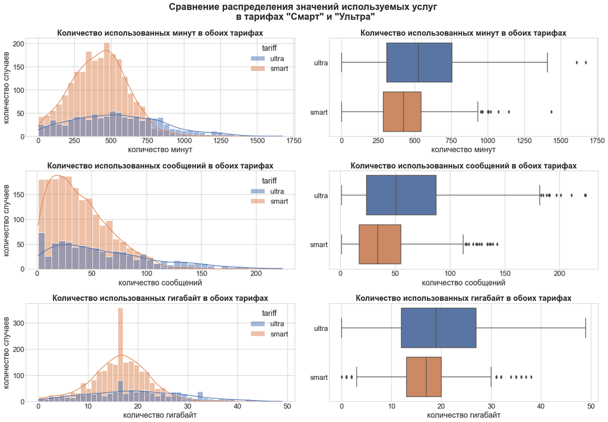

```python
plt.figure(figsize=(20, 15))
sns.set(font_scale=1.5)
plt.style.use('seaborn-whitegrid')
plt.suptitle('Сравнение распределения значений используемых услуг \n в тарифах "Смарт" и "Ультра"', fontweight='bold')


ax1 = plt.subplot(3, 2, 1)
sns.histplot(data=df, x='minutes_spent', kde=True, hue='tariff')
plt.title('Количество использованных минут в обоих тарифах', fontweight='bold')
plt.xlabel('количество минут')
plt.ylabel('количество случаев')

ax2 = plt.subplot(3, 2, 2)
sns.boxplot(data=df, x='minutes_spent', y='tariff')
plt.title('Количество использованных минут в обоих тарифах', fontweight='bold')
plt.xlabel('количество минут')
plt.ylabel('')

ax3 = plt.subplot(3, 2, 3)
sns.histplot(data=df, x='messages_spent', kde=True, hue='tariff')
plt.title('Количество использованных сообщений в обоих тарифах', fontweight='bold')
plt.xlabel('количество сообщений')
plt.ylabel('количество случаев')

ax4 = plt.subplot(3, 2, 4)
sns.boxplot(data=df, x='messages_spent', y='tariff')
plt.title('Количество использованных сообщений в обоих тарифах', fontweight='bold')
plt.xlabel('количество сообщений')
plt.ylabel('')

ax5 = plt.subplot(3, 2, 5)
sns.histplot(data=df, x='gb_spent', kde=True, hue='tariff')
plt.title('Количество использованных гигабайт в обоих тарифах', fontweight='bold')
plt.xlabel('количество гигабайт')
plt.ylabel('количество случаев')

ax6 = plt.subplot(3, 2, 6)
sns.boxplot(data=df, x='gb_spent', y='tariff')
plt.title('Количество использованных гигабайт в обоих тарифах', fontweight='bold')
plt.xlabel('количество гигабайт')
plt.ylabel('')

plt.tight_layout()
plt.show();
```

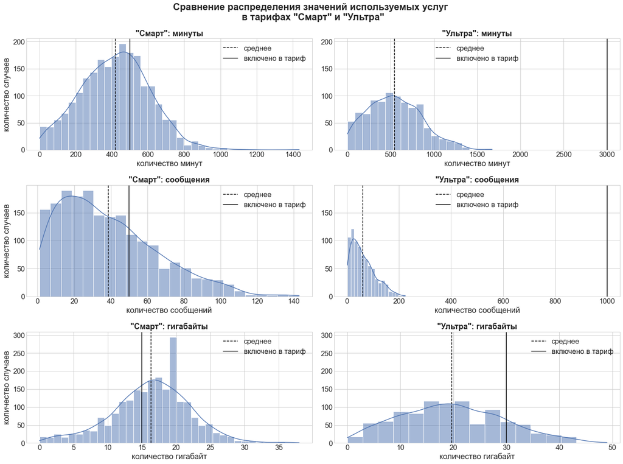

```python
plt.figure(figsize=(20, 15))
sns.set(font_scale=1.5)
plt.style.use('seaborn-whitegrid')
plt.suptitle('Сравнение распределения значений используемых услуг \n в тарифах "Смарт" и "Ультра"', fontweight='bold')

# первый график
ax1 = plt.subplot(3, 2, 1)
sns.histplot(data=df_smart, x='minutes_spent', kde=True)
plt.axvline(x=df_smart['minutes_spent'].mean(), color='black', linestyle='--', label='среднее')
plt.axvline(x=df_smart['minutes_included'].mean(), color='black', linestyle='-', label='включено в тариф')
plt.legend()
plt.title('"Смарт": минуты', fontweight='bold')
plt.xlabel('количество минут')
plt.ylabel('количество случаев')

# второй график
ax2 = plt.subplot(3, 2, 2, sharey=ax1)
sns.histplot(data=df_ultra, x='minutes_spent', kde=True)
plt.axvline(x=df_ultra['minutes_spent'].mean(), color='black', linestyle='--', label='среднее')
plt.axvline(x=df_ultra['minutes_included'].mean(), color='black', linestyle='-', label='включено в тариф')
plt.legend()
plt.title('"Ультра": минуты', fontweight='bold')
plt.xlabel('количество минут')
plt.ylabel('')

# третий график
ax3 = plt.subplot(3, 2, 3)
sns.histplot(data=df_smart, x='messages_spent', kde=True)
plt.axvline(x=df_smart['messages_spent'].mean(), color='black', linestyle='--', label='среднее')
plt.axvline(x=df_smart['messages_included'].mean(), color='black', linestyle='-', label='включено в тариф')
plt.legend()
plt.title('"Смарт": сообщения', fontweight='bold')
plt.xlabel('количество сообщений')
plt.ylabel('количество случаев')

# четвёртый график
ax4 = plt.subplot(3, 2, 4, sharey=ax3)
sns.histplot(data=df_ultra, x='messages_spent', kde=True)
plt.axvline(x=df_ultra['messages_spent'].mean(), color='black', linestyle='--', label='среднее')
plt.axvline(x=df_ultra['messages_included'].mean(), color='black', linestyle='-', label='включено в тариф')
plt.legend(loc='upper center')
plt.title('"Ультра": сообщения', fontweight='bold')
plt.xlabel('количество сообщений')
plt.ylabel('')

# пятый график
ax5 = plt.subplot(3, 2, 5)
sns.histplot(data=df_smart, x='gb_spent', kde=True)
plt.axvline(x=df_smart['gb_spent'].mean(), color='black', linestyle='--', label='среднее')
plt.axvline(x=df_smart['gb_per_month_included'].mean(), color='black', linestyle='-', label='включено в тариф')
plt.legend()
plt.title('"Смарт": гигабайты', fontweight='bold')
plt.xlabel('количество гигабайт')
plt.ylabel('количество случаев')

# шестой график
ax6 = plt.subplot(3, 2, 6, sharey=ax5)
sns.histplot(data=df_ultra, x='gb_spent', kde=True)
plt.axvline(x=df_ultra['gb_spent'].mean(), color='black', linestyle='--', label='среднее')
plt.axvline(x=df_ultra['gb_per_month_included'].mean(), color='black', linestyle='-', label='включено в тариф')
plt.legend()
plt.title('"Ультра": гигабайты', fontweight='bold')
plt.xlabel('количество гигабайт')
plt.ylabel('')

plt.tight_layout()
plt.show();
```

### Вывод

**Звонки:**

- пользователи тарифа "Смарт" в среднем используют 419 минут в месяц, в то время как в тариф включено 500 минут. Многие пользователи используют дополнительные минуты разговора, сверх тарифа, вплоть до 1000 минут в месяц
- пользователи тарифа "Ультра" разговаривают больше: в среднем они используют 545 минут разговоров в месяц, но это всё равно очень далеко от количества минут, включённых в тариф. Никто не использует 3000 минут, максимум - около 1500 минут в месяц

**Сообщения:**

- пользователи тарифа "Смарт" в среднем отправляют 39 сообщений в месяц, в то время как в тариф включено 50 сообщений. Многие пользователи отправляют больше сообщений, чем включено в тариф, вплоть до 140 в месяц
- пользователи тарифа "Ультра" активнее пользуются и этой услугой: в среднем они отправляют 61 сообщение в месяц, но это значение опять находится очень далеко от количества сообщений, включённых в тариф. Никто не использует 1000 сообщений за месяц, максимум - чуть больше 200

## Проверка гипотез

**1. Сравним выручки от пользователей тарифов "Ультра" и "Смарт".**

*Нулевая гипотеза:*

- средняя выручка тарифа "Смарт" равна средней выручке тарифа "Ультра"

*Альтернативная гипотеза:*

- средние выручки двух тарифов не равны

Получилась двусторонняя альтернативная гипотеза.

**2. Сравним выручки пользователей из Москвы и из других регионов.**

*Нулевая гипотеза:*

- средняя выручка пользователей из Москвы равна средней выручке пользователей из других регионов

*Альтерантивная гипотеза:*

- средние выручки не равны

### Сравнение средних выручек двух тарифов

Посмотрим, какого размера выборки для двух тарифов:

```python
len(df_smart)
```

```
2229
```

```python
len(df_ultra)
```

```
985
```

Поскольку мы работаем с гипотезами о равенстве средних двух генеральных совокупностей, спользуем метод scipy.stats.ttest_ind, куда в качестве аргументов передадим массивы, содержащие выборки для двух тарифов. Поскольку у нас выборки разного размера, укажем параметр equal_var=False.

```python
alpha = 0.05

results = st.ttest_ind(df_smart['revenue'], df_ultra['revenue'], equal_var=False)

print('p-значение:', results.pvalue)

if results.pvalue < alpha:
    print('Отвергаем нулевую гипотезу')
else:
    print('Не получилось отвергнуть нулевую гипотезу')
```

```
p-значение: 4.2606313931076085e-250
Отвергаем нулевую гипотезу
```

### Вывод

- вероятность получить такой результат маленькая, нулевая гипотеза отвергнута: вероятнее всего средние выручки двух тарифов не равны

### Сравнение средних выручек пользователей из Москвы и из регионов

Выделим отдельно выборку с пользователями из Москвы и из регионов:

```python
df_moscow = df.query('city == "Москва"')
df_regions = df.query('city != "Москва"')
```

Посмотрим на размер этих выборок:

```python
len(df_moscow)
```

```
611
```

```python
len(df_regions)
```

```
2603
```

```python
alpha = 0.05

results = st.ttest_ind(df_moscow['revenue'], df_regions['revenue'], equal_var=False)

print('p-значение:', results.pvalue)

if results.pvalue < alpha:
    print('Отвергаем нулевую гипотезу')
else:
    print('Не получилось отвергнуть нулевую гипотезу')
```

```
p-значение: 0.5257376663729298
Не получилось отвергнуть нулевую гипотезу
```

### Вывод

- Значение p-value показывает: вероятность случайно получить такое или большее различие равно почти 53%. Это слишком большая вероятность, чтобы делать вывод о значимом различии между средними выручками пользователей из Москвы и из регионов.

### Дополнение: графики сравнения выручек

Дополнительно визуализируем, как выглядит сравнение выручек на имеющихся выборках:

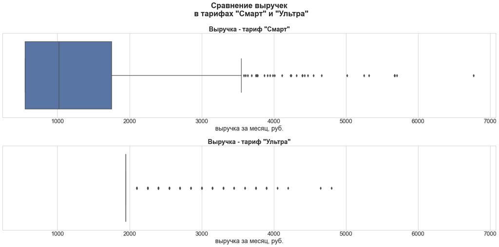

```python
plt.figure(figsize=(20, 10))
sns.set(font_scale=1.5)
plt.style.use('seaborn-whitegrid')
plt.suptitle('Сравнение выручек \n в тарифах "Смарт" и "Ультра"', fontweight='bold')

ax1 = plt.subplot(2, 1, 1)
sns.boxplot(x=df_smart['revenue'])
plt.title('Выручка - тариф "Смарт"', fontweight='bold')
plt.xlabel('выручка за месяц, руб.')

ax2 = plt.subplot(2, 1, 2, sharex=ax1)
sns.boxplot(x=df_ultra['revenue'])
plt.title('Выручка - тариф "Ультра"', fontweight='bold')
plt.xlabel('выручка за месяц, руб.')

plt.tight_layout()
plt.show();
```

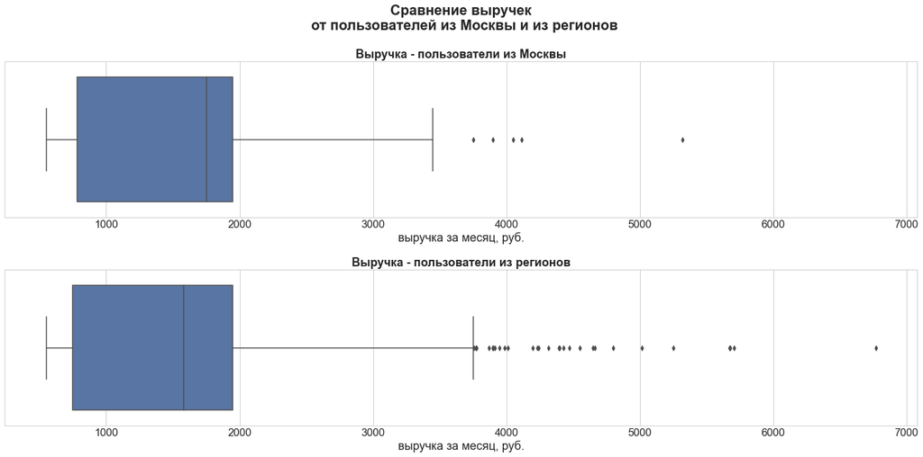

```python
plt.figure(figsize=(20, 10))
sns.set(font_scale=1.5)
plt.style.use('seaborn-whitegrid')
plt.suptitle('Сравнение выручек \n от пользователей из Москвы и из регионов', fontweight='bold')

ax1 = plt.subplot(2, 1, 1)
sns.boxplot(x=df_moscow['revenue'])
plt.title('Выручка - пользователи из Москвы', fontweight='bold')
plt.xlabel('выручка за месяц, руб.')

ax2 = plt.subplot(2, 1, 2, sharex=ax1)
sns.boxplot(x=df_regions['revenue'])
plt.title('Выручка - пользователи из регионов', fontweight='bold')
plt.xlabel('выручка за месяц, руб.')

plt.tight_layout()
plt.show();
```

### На какой тариф направить рекламный бюджет?

По результатам t-теста на выборке мы знаем, что вероятнее всего средние выручки двух тарифов не равны.

Благодаря графикам сравнения мы видим, что медианы выручек находятся в разных местах:

- у тарифа "Смарт" медиана около 1000,
- а у тарифа "Ультра" около 2000.

Теперь посмотрим, где находятся средние значения выручек тарифов. График поможет принять решение и сделает вывод наглядным:

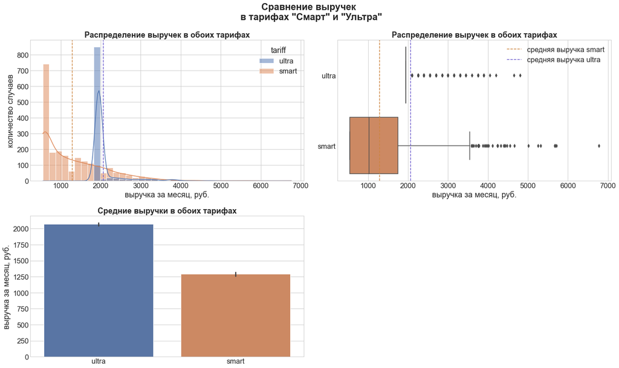

```python
plt.figure(figsize=(20, 12))
sns.set(font_scale=1.5)
plt.style.use('seaborn-whitegrid')
plt.suptitle('Сравнение выручек \n в тарифах "Смарт" и "Ультра"', fontweight='bold')

ax1 = plt.subplot(2, 2, 1)
sns.histplot(data=df, x='revenue', kde=True, hue='tariff')
plt.title('Распределение выручек в обоих тарифах', fontweight='bold')
plt.axvline(x=df_smart['revenue'].mean(), color='peru', linestyle='--', label='средняя выручка smart')
plt.axvline(x=df_ultra['revenue'].mean(), color='slateblue', linestyle='--', label='средняя выручка ultra')
plt.xlabel('выручка за месяц, руб.')
plt.ylabel('количество случаев')

ax2 = plt.subplot(2, 2, 2)
sns.boxplot(data=df, x='revenue', y='tariff')
plt.title('Распределение выручек в обоих тарифах', fontweight='bold')
plt.axvline(x=df_smart['revenue'].mean(), color='peru', linestyle='--', label='средняя выручка smart')
plt.axvline(x=df_ultra['revenue'].mean(), color='slateblue', linestyle='--', label='средняя выручка ultra')
plt.legend()
plt.xlabel('выручка за месяц, руб.')
plt.ylabel('')

ax3 = plt.subplot(2, 2, 3)
sns.barplot(data=df, x='tariff', y='revenue')
plt.title('Средние выручки в обоих тарифах', fontweight='bold')
plt.xlabel('')
plt.ylabel('выручка за месяц, руб.')

plt.tight_layout()
plt.show();
```

### Вывод

Если учитывать только выручку, то рекламный бюджет стоит направить на этот тариф.

Однако в этом анализе не учтены расходы компании на предоставление услуг. Да, тариф "Ультра" приносит больше денег, но ведь и по условиям тарифа предоставляет гораздо больший объём услуг (в 6 раз больше минут, в 20 раз больше сообщений, в 2 раза больше гигабайт).

Но, даже не зная затрат компании, можно обратить внимание на фактический уровень потребления услуг. На предоставленной выборке мы видим, что пользователи тарифа "Ультра" в основном не используют полный объём включённых в тариф услуг. Пользователи "Ультра" потребляют больше, чем пользователи тарифа "Смарт", но не в разы:

- 545 мин против 419 минут,
- 61 сообщение против 39,
- 20 Гб против 16.

Всё это в совокупности подтверждает: **для компании тариф "Ультра" выгоднее, рекламный бюджет стоит направить на него**.

## Общий вывод

**В процессе подготовки:**

- данные были приведены к нужным типам
- был убран лишний столбец из таблицы internet

По каждому пользователю были проведены следующие расчёты:

- количество сделанных звонков и израсходованных минут разговора по месяцам;
- количество отправленных сообщений по месяцам;
- объем израсходованного интернет-трафика по месяцам;
- помесячная выручка с каждого пользователя.

В процессе исследования был проведён **анализ поведения пользователей** по всем предоставляемым услугам.

**Звонки:**

- пользователи тарифа "Смарт" в среднем используют 419 минут в месяц, в то время как в тариф включено 500 минут. Многие пользователи используют дополнительные минуты разговора, сверх тарифа, вплоть до 1000 минут в месяц
- пользователи тарифа "Ультра" разговаривают больше: в среднем они используют 545 минут разговоров в месяц, но это всё равно очень далеко от количества минут, включённых в тариф. Никто не использует 3000 минут, максимум - около 1500 минут в месяц

**Сообщения:**

- пользователи тарифа "Смарт" в среднем отправляют 39 сообщений в месяц, в то время как в тариф включено 50 сообщений. Многие пользователи отправляют больше сообщений, чем включено в тариф, вплоть до 140 в месяц
- пользователи тарифа "Ультра" активнее пользуются и этой услугой: в среднем они отправляют 61 сообщение в месяц, но это значение опять находится очень далеко от количества сообщений, включённых в тариф. Никто не использует 1000 сообщений за месяц, максимум - чуть больше 200

Были сформулированы и проверены следующие гипотезы:

**1. Сравнение выручек от пользователей тарифов "Ультра" и "Смарт".**

*Нулевая гипотеза:*

- средняя выручка тарифа "Смарт" равна средней выручке тарифа "Ультра"

*Альтернативная гипотеза:*

- средние выручки двух тарифов не равны

Получилась двусторонняя альтернативная гипотеза. **T-тест показал: нулевая гипотеза отвергнута. Вероятнее всего средние выручки двух тарифов в генеральных совокупностях не равны.**

**2. Сравнение выручек пользователей из Москвы и из других регионов.**

*Нулевая гипотеза:*

- средняя выручка пользователей из Москвы равна средней выручке пользователей из других регионов

*Альтерантивная гипотеза:*

- средние выручки не равны

Полученное в ходе t-теста значение p-value показало: **вероятность случайно получить такое или большее различие равно почти 53%. Это слишком большая вероятность, чтобы делать вывод о значимом различии между средними выручками пользователей из Москвы и из регионов.**

**На какой тариф направить рекламный бюджет?**

Если учитывать только выручку, то рекламный бюджет стоит направить на этот тариф.

Однако в этом анализе не учтены расходы компании на предоставление услуг. Да, тариф "Ультра" приносит больше денег, но ведь и по условиям тарифа предоставляет гораздо больший объём услуг (в 6 раз больше минут, в 20 раз больше сообщений, в 2 раза больше гигабайт).

Но, даже не зная затрат компании, можно обратить внимание на фактический уровень потребления услуг. На предоставленной выборке мы видим, что пользователи тарифа "Ультра" в основном не используют полный объём включённых в тариф услуг. Пользователи "Ультра" потребляют больше, чем пользователи тарифа "Смарт", но не в разы:

- 545 мин против 419 минут,
- 61 сообщение против 39,
- 20 Гб против 16.

Всё это в совокупности подтверждает: **для компании тариф "Ультра" выгоднее, рекламный бюджет стоит направить на него**.

Исследование выполнила: аналитик данных Малахова Наталья

Мой телеграм-канал: [Дневник аналитика](https://t.me/diary_musician_analyst)

Портфолио: [GitHub](https://github.com/Malakhova-Natalya)

Спасибо за внимание!